# Reproducable Research: Project 1

# Imputing missing values

Note that there are a number of days/intervals where there are missing values (coded as NA). The presence of missing days may introduce bias into some calculations or summaries of the data.

1. Calculate and report the total number of missing values in the dataset (i.e. the total number of rows with NAs)

```r
sum(is.na(mData$steps))
```

```
## [1] 2304
```

2. Devise a strategy for filling in all of the missing values in the dataset. The strategy does not need to be sophisticated. For example, you could use the mean/median for that day, or the mean for that 5-minute interval, etc.

```r
# create logical vector for steps values that are NA
nData <- mData

rowsNA <- is.na(nData$steps)
```

3. Create a new dataset that is equal to the original dataset but with the missing data filled in.

```r
# the mean of daily steps is 10770 from Q#3 above. There are 288 5 min intervals per day.

nData$steps[rowsNA] = 10770/288
```

4. Make a histogram of the total number of steps taken each day and Calculate and report the mean and median total number of steps taken per day.

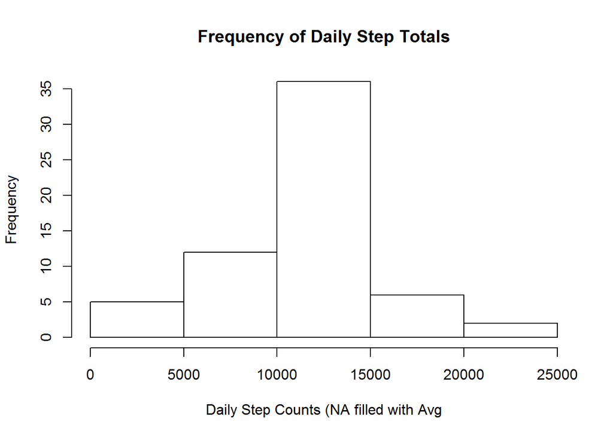

```r
by_Datn <- group_by(nData, date)

t_Steps <- summarise(by_Datn, sum(steps))

hist(t_Steps$`sum(steps)`, breaks=6, main = "Frequency of Daily Step Totals", xlab="Daily Step Counts (NA filled with Avg")
```

```r
summary(t_Steps$`sum(steps)`)
```

```
##    Min. 1st Qu.  Median    Mean 3rd Qu.    Max.
##      41    9819   10770   10770   12810   21190
```

5. Do these values differ from the estimates from the first part of the assignment? What is the impact of imputing missing data on the estimates of the total daily number of steps?

Answer: The histrogram frequencies are higher, but the MEAN did not change.

## Are there differences in activity patterns between weekdays and weekends?

```r
nData$day <- weekdays(nData$date)

nData$week <- NULL

nrows <- nrow(nData)

for(i in 1:nrows){

        if(nData$day[i] == "Saturday" | nData$day[i] == "Sunday") {

         nData$week[i] <- "wkEnd"

        }

        else
        {
         nData$week[i] <- "wkDay"

        }

}

nData$week <- as.factor(nData$week)

str(nData)
```

```
## 'data.frame':    17568 obs. of  5 variables:
##  $ steps   : num  37.4 37.4 37.4 37.4 37.4 ...
##  $ date    : Date, format: "2012-10-01" "2012-10-01" ...
##  $ interval: int  0 5 10 15 20 25 30 35 40 45 ...
##  $ day     : chr  "Monday" "Monday" "Monday" "Monday" ...
##  $ week    : Factor w/ 2 levels "wkDay","wkEnd": 1 1 1 1 1 1 1 1 1 1 ...
```

2. Make a panel plot containing a time series plot (i.e. type = “l”) of the 5-minute interval (x-axis) and the average number of steps taken, averaged across all weekday days or weekend days (y-axis).

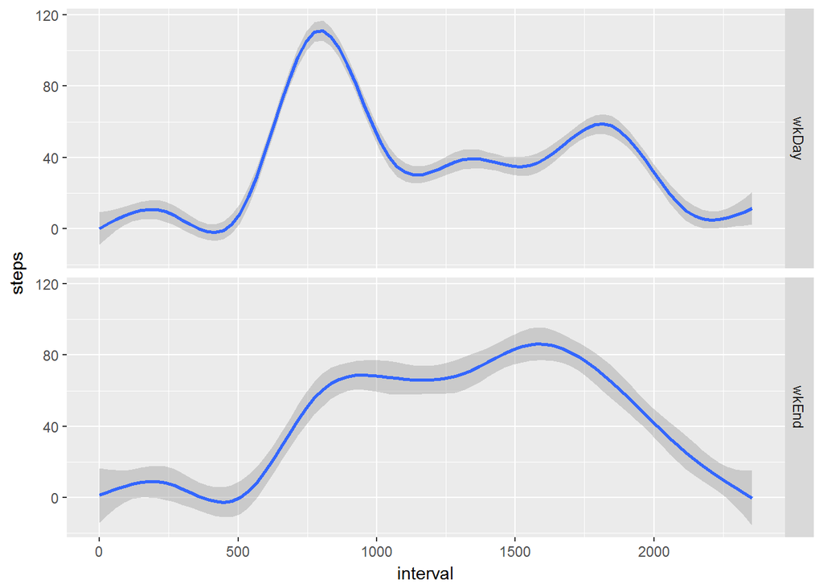

```r
qplot(interval, steps, data=nData, geom="smooth", facets =week~.)
```

```r
# strangely, if I use geom="line", the result is incorrect
```

end